# Datenvisualiserung 1

## 4.3 Layer 3: adding observations

- we don’t see any observations (i.e., the bars) on the plot, why not?
  - we haven’t told `ggplot()` how to visualise them
- we have to define a **geom**: the *geom*etrical object that a plot uses to represent data
  - in `ggplot2`, geom functions start with `geom_`
  - we often describe plots in terms of types of geoms they use, e.g., bar charts use bar geoms (`geom_bar()`), line charts use line geoms (`geom_line()`), scatterplots use a point geom (`geom_point()`), etc.
- let’s create our histogram using the geom `geom_histogram()`

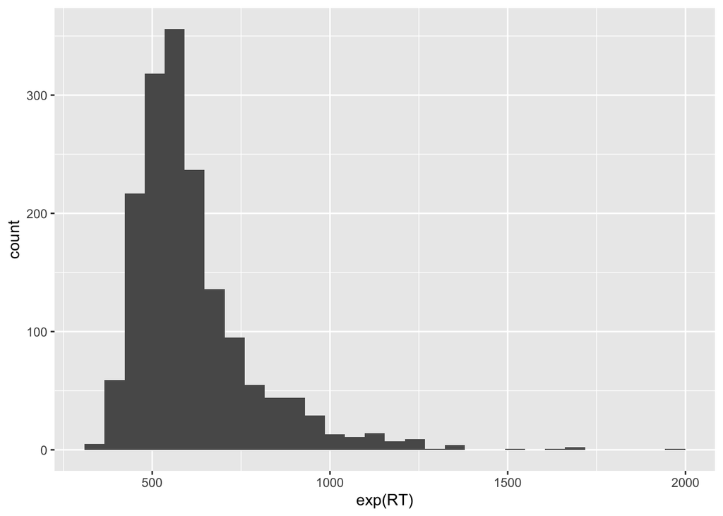

```r
ggplot(data = df_lexdec) +
  aes(x = exp(RT)) +
  geom_histogram()
```

**Note**

> `stat_bin()` using `bins = 30`. Pick better value with `binwidth`.

This is just telling us about the width of our bars: each bar represents a range of possible reaction time values + `bins = 30` simply means there are 30 bars, we can change this have more or fewer bars by including e.g., `bins = 20` or `bins = 100` inside `geom_histogram()`

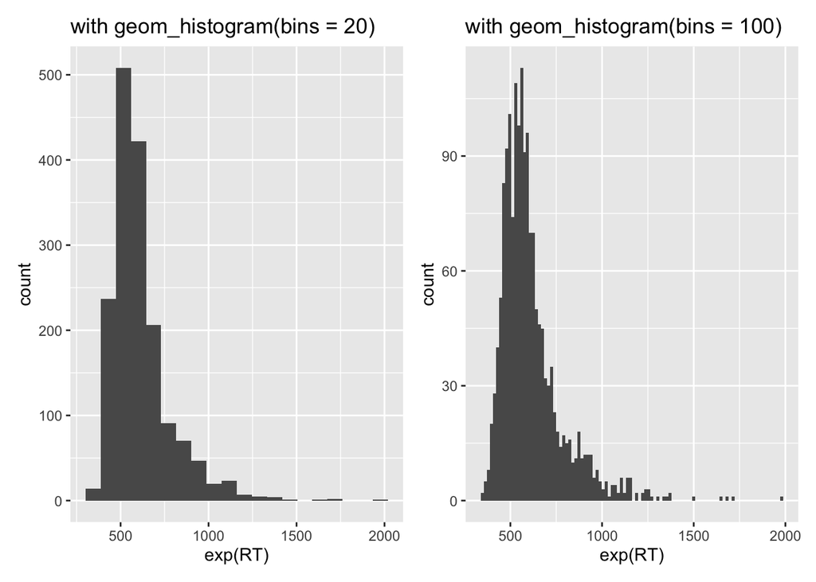

```r
ggplot(
  data = df_lexdec,
  mapping = aes(x = exp(RT))
) +
  labs(title = "with geom_histogram(bins = 20)") +
  geom_histogram(bins = 20) +

  ggplot(
  data = df_lexdec,
  mapping = aes(x = exp(RT))
) +
  labs(title = "with geom_histogram(bins = 100)") +
  geom_histogram(bins = 100)
```

## 4.4 Adding aesthetics

- seeing the distribution of reaction times in general is useful
  - but we usually want to compare groups
  - e.g., differences between native and non-native speakers, or between types of words
- we also have native language as a variable, how might we visualise this in our plot?

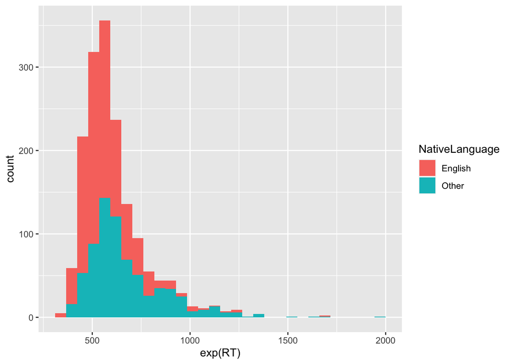

```r
ggplot(
  data = df_lexdec,
  aes(x = exp(RT), fill = NativeLanguage)
) +
  geom_histogram()
```

- we see the red bars and the blue bars, but is the blue histogram layered on top of the red?
  - or are the red bars stacked in top of the blue bars?
- it’s the latter
  - let’s make is so that the blue histogram is layered on top of the red

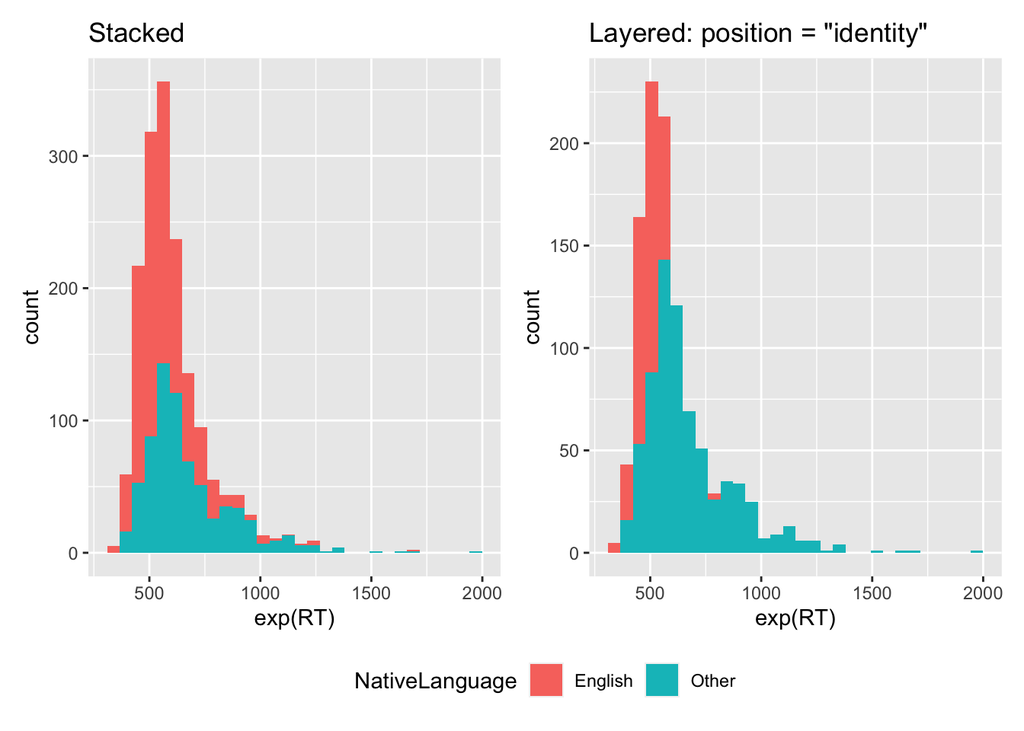

```r
ggplot(
  data = df_lexdec,
  aes(x = exp(RT), fill = NativeLanguage)
) +
  labs(title = "Stacked") +
  geom_histogram() +

ggplot(
  data = df_lexdec,
  aes(x = exp(RT), fill = NativeLanguage)
) +
  labs(title = "Layered: position = \"identity\"") +
  geom_histogram(position = "identity") +


  plot_layout(guides = "collect") & theme(legend.position = 'bottom')
```

## 4.5 Global and local aesthetics

- in our final plot, the colour of the histograms is slightly transparent
  - we can control this by adding the argument `alpha = 0.3` to `geom_histogram()`
  - alpha takes any other value between 0 and 1

**Aufgabe 3: Histogram transparency**

**Example 3**

Play around with the transparency of the histogram geom. Choose the alpha-value you prefer. The output should look something like this:

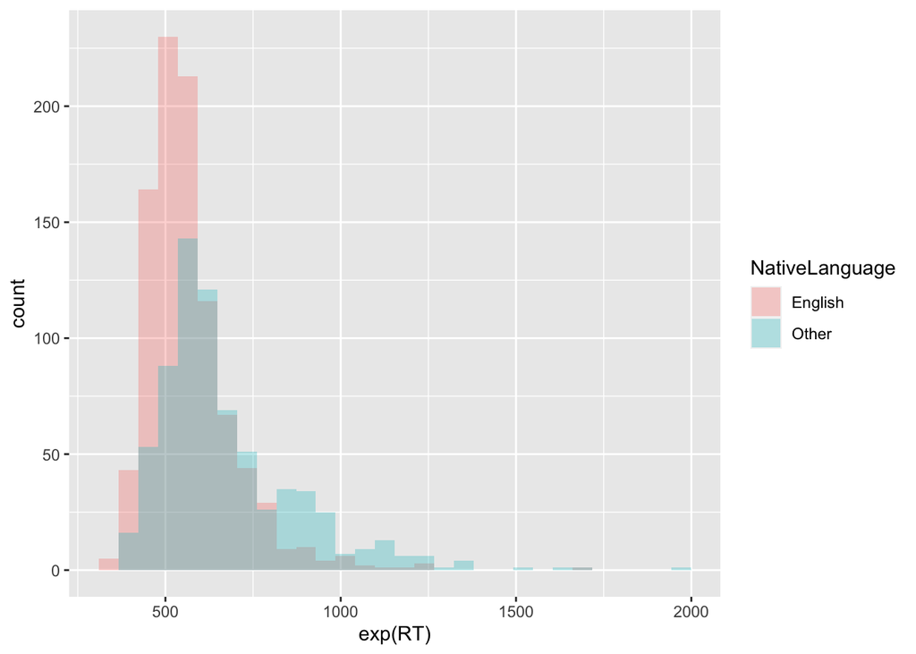

## 4.6 Customising our plot

- we can improve our axis and legend labels, and also add titles using the `labs()` function
- let’s also use the function `scale_fill_colorblind()` from the `ggthemes` package
  - this creates colourblind-safe colours
- we’ll also use the `theme_minimal()` function from `ggplot2`; what does this do?
- try to add the following to your plot
  - change the labels accordingly
  - and add meaningful comments to the code using `#`

```r
labs(title = "Plot title",
     x = "x-axis label",
     y = "y-axis label") +
  scale_fill_colourblind() +
  theme_minimal()
```

## 4.7 Commenting

- the code and plot should look something like this:

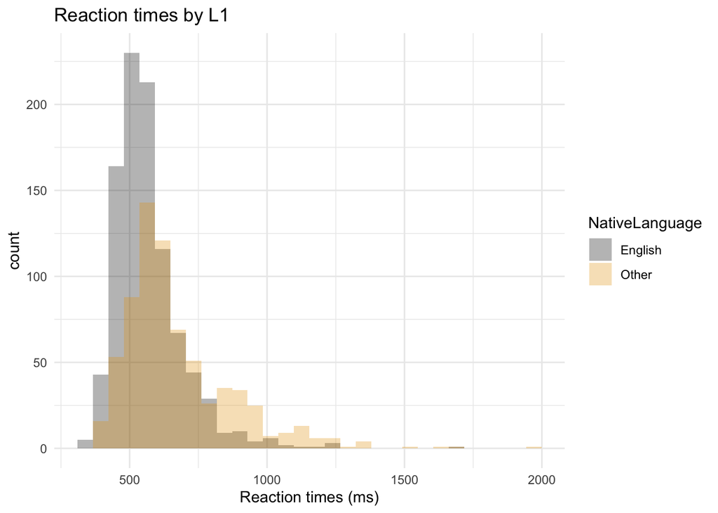

```r
# histogram of reaction times by native language
ggplot(data = df_lexdec) +
  aes(x = exp(RT), fill = NativeLanguage) + # set aesthetics
  labs(title = "Reaction times by L1",
     x = "Reaction times (ms)") +
  geom_histogram(position = "identity", alpha = 0.3) +
  scale_fill_colorblind() + # make fill colorblind friendly
  theme_minimal() # set plot theme
```

## 4.8 Saving plots

- we can store plots in our Environment, just like we can store numbers and data as objects
  - you can name objects anything you want
  - but it’s wise to make the name meaningful (e.g., *not* `fig1` or `xyz`)
- let’s name this plot `fig_lexdec_rt`, for “figure lexical decision task reaction times”

**Aufgabe 4: `ggplot2` review**

**Example 4**

1. Save our final plot as an object called `fig_lexdec_rt`

## 4.10

- the plot should look something like this:

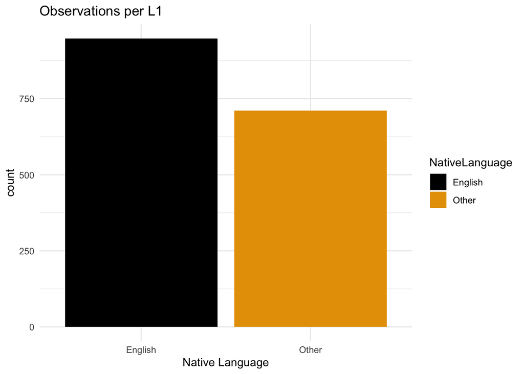

## 4.11 Combining plots

- one reason to save your plot as an object is so that we can call on it later
  - i.e., you can produce the plot at one point in your document, but decide to only print it in the rendered report lower down
- another reason is so that we can combine multiple plots
  - this can be done with a variety of packages
  - but let’s try it with the `patchwork` package
  - use `+` to connect two plots side-by-side
  - or `/` to present them one on top of the other

### 4.11.1 Combining plots with `+`

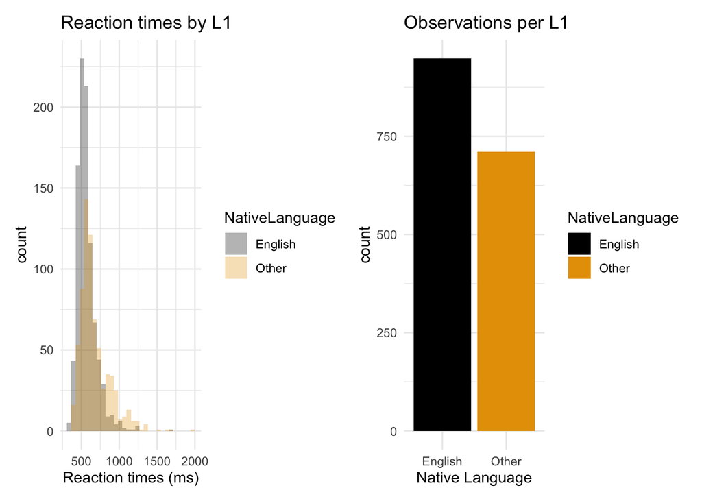

```r
fig_lexdec_rt + fig_lexdec_l1
```

### 4.11.2 Combining plots with `/`

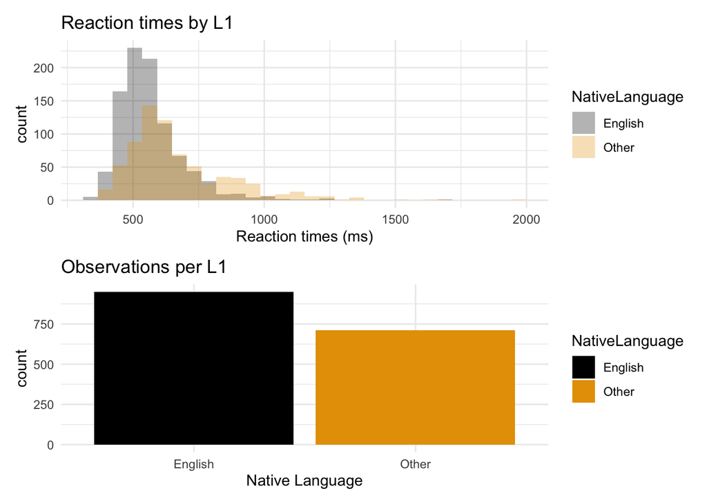

```r
fig_lexdec_rt / fig_lexdec_l1
```

# 5 Deciding on a geom

- why do we use histogram for reaction times, and a barplot for native language?
- what types of variables are these?
  - reaction time is continuous
  - native language is categorical
- we use histograms to visualise distributions of *continuous* variables
- we use barplots to visualise distributions of *cateogrical* variables
- knowing what we want to visualise (e.g., distributions) and what type of variable we have (i.e., continuous, categorical) helps us decide which type of plot to produce
- often, trying to draw your plot on paper before you start in R is a good idea (I often do this, too)

# 6 Exercises

These exercises should be also be included in your script if you upload it to Moodle. Working through the class materials will prepare you for these tasks.

1. Reproduce our histogram as a *density plot* by replacing `geom_histogram()` with `geom_density()`
   - what does this type of plot show?
2. Produce a barplot that shows the number of observations per word class (hint: you’ll need the variable `Class` from our dataset).
3. Print your density plot and class barplot one on top of the other using the `patchwork` package

## 6.1

4. Reproduce the following plots as exactly as you can (hint: you will need the `position = "dodge"` argument):

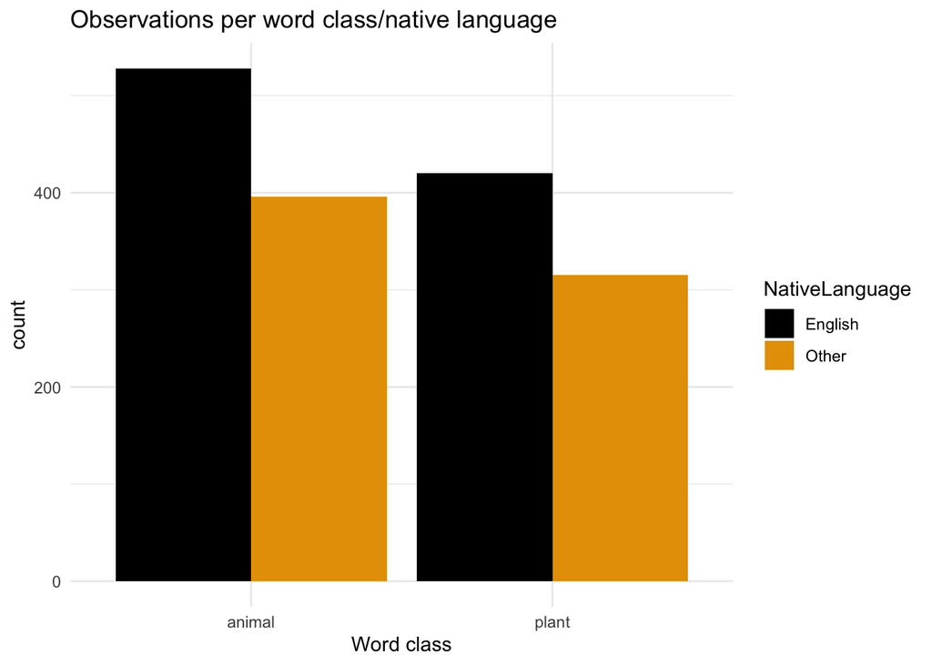

# Heutige Ziele

Today we learned…

- what data frames are
- the difference between categorical and continuous data
- how to produce plots with `ggplot`
- choose the right plot for our data

# Session Info

Hergestellt mit R version 4.3.0 (2023-04-21) (Already Tomorrow) und RStudioversion 2023.3.0.386 (Cherry Blossom).

# Literaturverzeichnis

Baayen, R. H. (2008). *Analyzing Linguistic Data: A Practical Introduction to Statistics using R*.

Nordmann, E., & DeBruine, L. (2022). *Applied data skills*. Zenodo. https://doi.org/10.5281/zenodo.6365078

Wickham, H., Çetinkaya-Rundel, M., & Grolemund, G. (2023). *R for Data Science* (2nd ed.).